# Geog533 Lab 10

Yang_Yalin

## Question 1

Use R package UScensus2010county to complete the following tasks: (20 pt.)

### Question 1(a)

Plot a map of New York counties using the plot function.

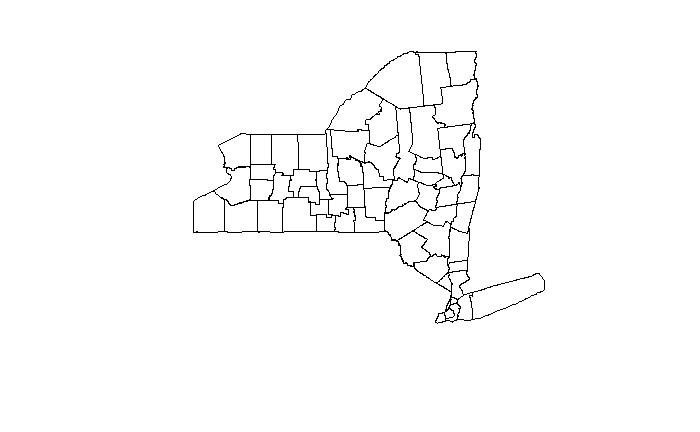

### Question 1(b)

Plot a map of New York counties using the qtm function.

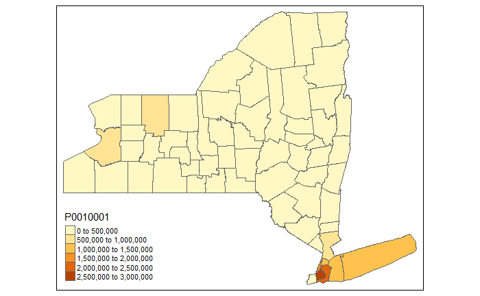

```r
library(tmap)
qtm(shp,fill = "P0010001")
```

### Question 1(c)

How many counties in New York State?

```r
df <- shp@data
nc <- table(df$county)
nrow(nc)
```

```
[1] 62
```

### Question 1(d)

What’s the 3-digit fips code of Broome County?

```r
data(countyfips)
df_fips <- countyfips[countyfips$statename == "new_york",]
fips.code <- df_fips[df_fips$countyname == 'broome county',]['fips']
fips <- gsub('\\s+','',paste("00",as.numeric(fips.code[[1]][1]) %% 100))
fips
```

```
[1] "007"
```

### Question 1(e)

Compute descriptive statistics of the population column (P0010001), including total, minimum, maximum, mean, median, and skewness.

```r
library(moments)
sum(df$P0010001)
```

```
[1] 19378102
```

```r
summary(df$P0010001)
```

```
   Min. 1st Qu.  Median    Mean 3rd Qu.    Max.
   4836   51244   91301  312550  231060 2504700
```

```r
skewness(df$P0010001)
```

```
[1] 2.579801
```

### Question 1(f)

Create a histogram and a boxplot of the population.

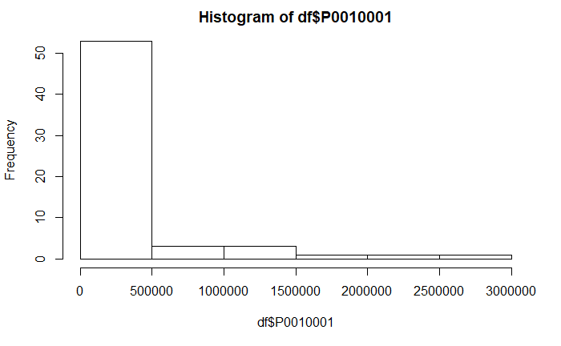

```r
hist(df$P0010001)
```

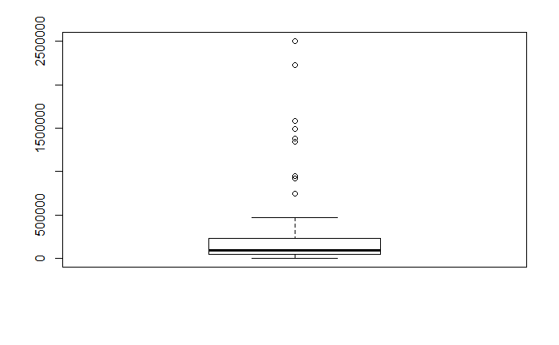

```r
boxplot(df$P0010001)
```

## Question 2

Use R package UScensus2010tract to complete the following tasks: (20 pt.)

### Question 2(a)

Plot a map of New York census tracts using the plot function.

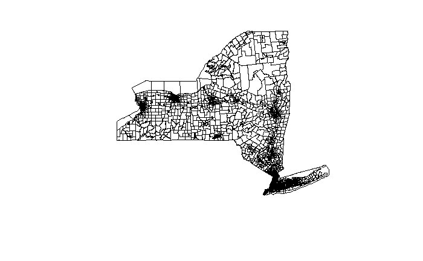

```r
data("new_york.tract10")
shp_new <- new_york.tract10
plot(shp_new)
```

### Question 2(b)

Compute the total population based on census tracts.

```r
data_p <- shp_new@data
sum(data_p$P0010001)
```

```
[1] 19378102
```

### Question 2(c)

Select all census tracts in Broome County and plot the map.

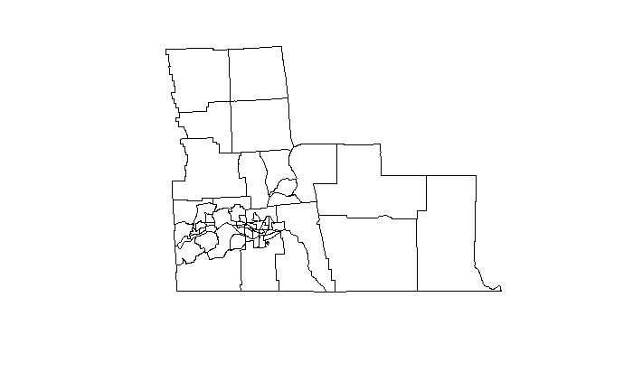

```r
shp_broome <- shp_new[shp_new$county == '007',]
plot(shp_broome)
```

### Question 2(d)

What’s the total population of Broome County?

```r
df_broome <- shp_broome@data
sum(df_broome$P0010001)
```

```
[1] 200600
```

### Question 2(e)

Create a histogram and a boxplot of population based on census tracts of Broome County.

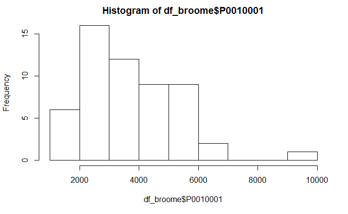

```r
hist(df_broome$P0010001)
```

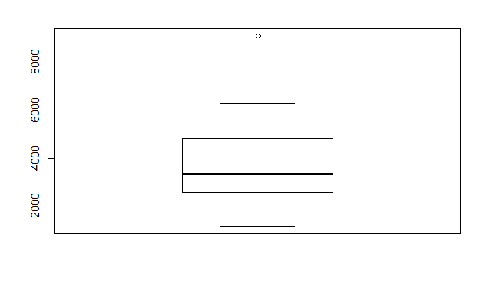

```r
boxplot(df_broome$P0010001)
```

### Question 2(f)

Select the first five columns of the shapefile of Broome County census tract; add a new population ratio column (= census tract population / county population); save the new shapefile to the hard drive.

```r
library(rgdal)
shp_write <- shp_broome[,1:5]
shp_write
```

```
class       : SpatialPolygonsDataFrame
features    : 55
extent      : -76.13018, -75.35958, 41.99779, 42.4157  (xmin, xmax, ymin, ymax)
coord. ref. : +proj=longlat +ellps=GRS80 +datum=NAD83 +no_defs +towgs84=0,0,0
variables   : 5
names       : state, county,  tract,        fips, P0010001
min values  :    36,    007, 000100, 36007000100,     1173
max values  :    36,    007, 014600, 36007014600,     9094
```

```r
df_write <- shp_write@data
df_write$ratio <- df_write$P0010001/sum(df_broome$P0010001)
shp_write@data <- df_write
writeOGR(shp_write,dsn = "output",layer = "shp_write",driver = "ESRI Shapefile",overwrite_layer = TRUE)
```

```
NAs introduced by coercion
```

```r
shp_read <- readOGR(dsn = "output", layer = "shp_write")
```

## Question 3

Use R packages raster and ncdf4 to complete the following tasks: (20 pt.)

### Question 3(a)

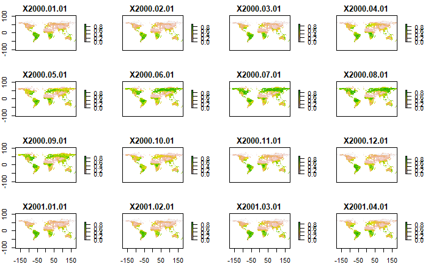

```r
library(ncdf4)
library(raster)
ndvi <-  brick("NDVI.nc")
plot(ndvi)
```

### Question 3(b)

Get the basic information about the dataset, including the number of rows, columns, cells, and bands; spatial resolution, extent, bounding box, and projection.

```r
nrow(ndvi)
```

```
[1] 360
```

```r
ncol(ndvi)
```

```
[1] 720
```

```r
ncell(ndvi)
```

```
[1] 259200
```

```r
extent(ndvi)
```

```
class       : Extent
xmin        : -180
xmax        : 180
ymin        : -90
ymax        : 90
```

```r
bbox(ndvi)
```

```
    min max
s1 -180 180
s2  -90  90
```

```r
res(ndvi)
```

```
[1] 0.5 0.5
```

```r
projection(ndvi)
```

```
[1] "+proj=longlat +datum=WGS84 +ellps=WGS84 +towgs84=0,0,0"
```

```r
ndvi@file@nbands
```

```
[1] 36
```

### Question 3(c)

Aggregate all bands to generate a mean NDVI raster and a maximum NDVI raster; save the two new raster datasets to the hard drive.

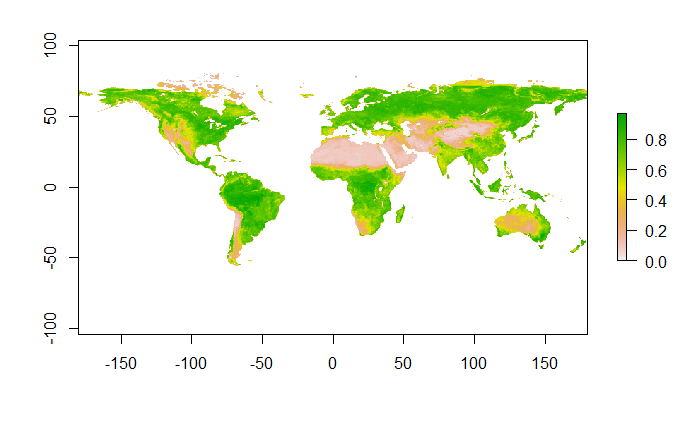

```r
ndvi.rb <- brick("NDVI.nc")
ndvi.rb.mean <- mean(ndvi.rb)
ndvi.rb.max <- max(ndvi.rb)
plot(ndvi.rb.max)
```

### Question 3(d)

Plot the maps of monthly NDVI of the year 2001

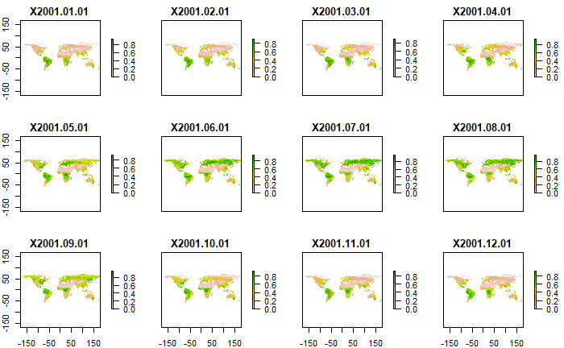

```r
plot(ndvi.rb[[13:24]])
```

```r
ndvi.rb
```

```
class       : RasterBrick
dimensions  : 360, 720, 259200, 36  (nrow, ncol, ncell, nlayers)
resolution  : 0.5, 0.5  (x, y)
extent      : -180, 180, -90, 90  (xmin, xmax, ymin, ymax)
coord. ref. : +proj=longlat +datum=WGS84 +ellps=WGS84 +towgs84=0,0,0
data source : E:\1Year2\R\lab\New folder\Yang_Yalin_Lab10\NDVI.nc
names       : X2000.01.01, X2000.02.01, X2000.03.01, X2000.04.01, X2000.05.01, X2000.06.01, X2000.07.01, X2000.08.01, X2000.09.01, X2000.10.01, X2000.11.01, X2000.12.01, X2001.01.01, X2001.02.01, X2001.03.01, ...
Date        : 2000-01-01, 2002-12-01 (min, max)
varname     : NDVI
```

### Question 3(e)

Create histograms of monthly NDVI of the year 2001.

```
size changed to n because it cannot be larger than n when replace is FALSE39% of the raster cells were used (of which 42% were NA). 58093 values used.
```

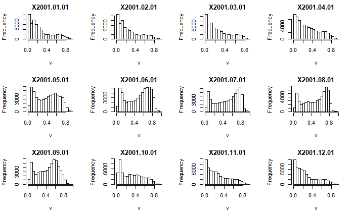

### Question 3(f)

Plot the NDVI map of July 2000; click any location with data on the map and retrieve the NDVI time series for all years; plot the NDVI time series of the selected location.

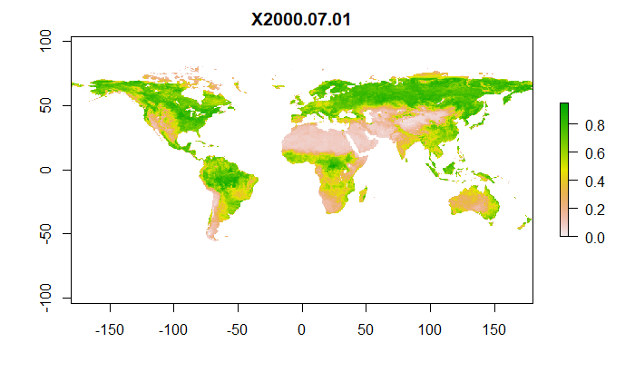

```r
plot(ndvi.rb,7)
```

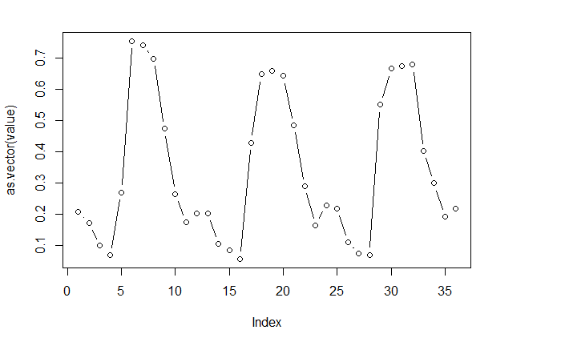

```r
value <- ndvi.rb[50,50]
plot(as.vector(value), type="b")
```